# Working Paper 5

# 1. Data Description

The Ministry of Education provides information regarding the salaries obtained by graduates and other related information at the website ”http://graduate.edu.ru”. A key purpose of this website is to provide accurate information to prospective university students and their families about the prospects of graduates from each of the universities or colleges. The Ministry of Finance collects information from all education establishments and others providing public service as a means to foster citizen engagement and accountability.This information includes details about revenue and income streams. This paper presents analysis from the merger of these two databases. The content of the data is presented in this section. Subsequent sections provide analysis and interpretation.

## 1.1. Graduate.edu portal

Graduate.edu allows the registered users to download all desirable information about the earnings of college or university graduates in .xlsx format. By using that service we obtained data about the number of graduates in 2013 in each university and college and their corresponding salaries in 2014, 2015 and 2016. Our final set of data consists of 1909 colleges, 423 universities, and 2975 pairs of university-study areas with information about the graduates earning in them. We filtered out universities and colleges with less than 100 and 50 graduates in 2013, respectively. Salaries in 2014 and 2015 were adjusted to the prices of 2016.

|  | Mean | Std | Quantile.25. | Quantile.50. | Quantile.75. |
| --- | --- | --- | --- | --- | --- |
| College Graduates Avg. Earnings 2014 | 301,255 | 81,712 | 247,093 | 279,156 | 328,995 |
| College Graduates Avg. Earnings 2015 | 281,567 | 76,821 | 229,697 | 261,667 | 311,208 |
| College Graduates Avg. Earnings 2016 | 287,918 | 80,574 | 233,763 | 267,480 | 320,583 |
| University Graduates Avg. Earnings 2014 | 411,050 | 152,936 | 300,829 | 365,771 | 481,628 |
| University Graduates Avg. Earnings 2015 | 419,488 | 158,256 | 304,798 | 368,518 | 496,961 |
| University Graduates Avg. Earnings 2016 | 433,387 | 175,586 | 305,856 | 380,304 | 508,152 |

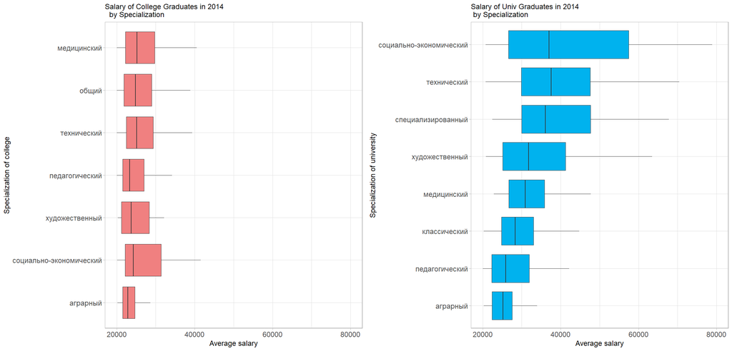

```r
### 1. Create dataframes with russian-english names

# University names
university_specialization_names <- data.frame(russian_name=c("аграрный", "классический", "педагогический", "медицинский",
                                                      "специализированный", "социально-экономический", "технический",
                                                      "художественный"),
                                       english_name=c("Agricultural", "Classical", "Pedagogical", "Medical",
                                                      "Specialized", "Socio-economic", "Technical", "Art"))

# College names
college_specialization_names <- data.frame(russian_name=c("аграрный", "педагогический", "медицинский",
                                                      "общий", "социально-экономический", "технический",
                                                      "художественный"),
                                          english_name=c("Agricultural", "Pedagogical", "Medical",
                                                      "General", "Socio-economic", "Technical", "Art"))

# Study area names
area_names <- rio::import("C:/Country/Russia/Data/SEASHELL/SEABYTE/edreru/wp5/area_names.xlsx", "xlsx")

# Region names
region_names <- rio::import("C:/Country/Russia/Data/SEASHELL/SEABYTE/edreru/wp3/rgnames2.xlsx", "xlsx")
region_names <- region_names %>% rename(region_name = en_rgnames)

df_universities <- df_universities[nchar(df_universities$OKATO) == 2,]
df_colleges <- df_colleges[nchar(df_colleges$OKATO) == 2,]

df_colleges$region_name <- (df_colleges %>% dplyr::select(OKATO) %>% left_join(region_names))$region_name
df_universities$region_name <- (df_universities %>% dplyr::select(OKATO) %>% left_join(region_names))$region_name
### 2. Rename

# Universities
df_temp <- df_universities %>% dplyr::select(specialization_type) %>% left_join(university_specialization_names,
                                                             by=c("specialization_type"="russian_name"))
```

```
Column `specialization_type`/`russian_name` joining character vector and factor, coercing into character vector
```

```r
df_universities$specialization_type <- df_temp$english_name

# Colleges
df_temp <- df_colleges %>% dplyr::select(speciality_type) %>% left_join(college_specialization_names,
                                                             by=c("speciality_type"="russian_name"))
```

```
Column `speciality_type`/`russian_name` joining character vector and factor, coercing into character vector
```

```r
df_colleges$speciality_type <- df_temp$english_name

# Study areas
df_temp <- df_universities_areas %>% dplyr::select(area_name) %>% left_join(area_names,
                                                                 by=c("area_name"="russian_name"))
df_universities_areas$area_name <- df_temp$english_name
```

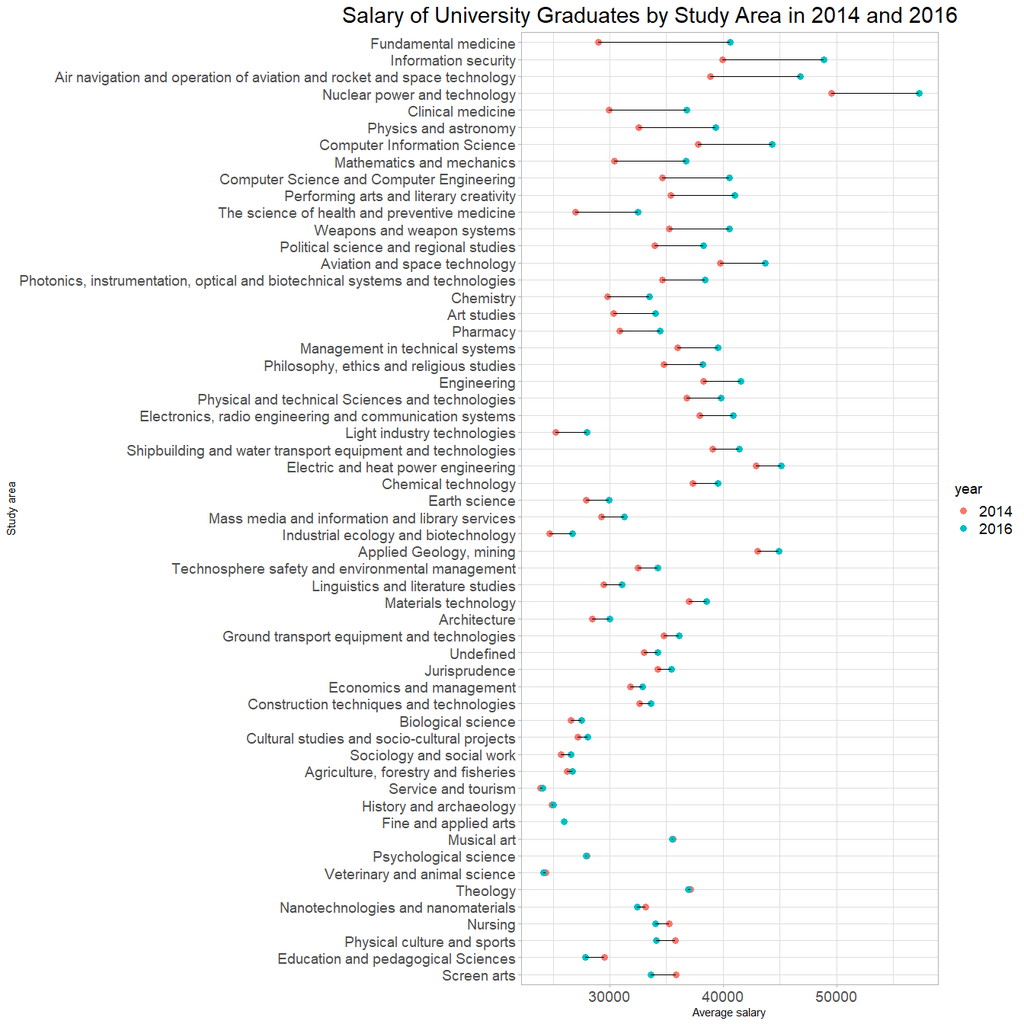

## 1.2. Bus.gov.ru portal

We obtained financial data about the colleges and universities from the open data section on the https://bus.gov.ru. It contains information about the total cash receipts of an organization for a given year and provides data on the income subcategories, such as cash receipts from paid services, target subsidy, budget investments, state (municipal) tasks. In our research, we approximated fee payments through the information about cash receipts from the paid services and used it together with the number of graduates for the calculation of the private education cost. To estimate the social cost of education we used total cash receipts in an organization

|  | Mean | Std | Quantile.25. | Quantile.50. | Quantile.75. |
| --- | --- | --- | --- | --- | --- |
| Number of College Graduates in 2013 | 192 | 149 | 97 | 155 | 243 |
| Total Cash Receipts in Colleges, mean 2012-2017 | 106,233,973 | 251,105,561 | 47,882,033 | 70,179,595 | 109,940,985 |
| Cash Receipts from the Paid Services in Colleges, mean 2012-2017 | 13,423,225 | 14,185,670 | 4,220,980 | 8,290,917 | 17,147,603 |
| Cash Receipts from the Target Subsidy in Colleges, mean 2012-2017 | 13,644,089 | 87,268,649 | 2,973,843 | 6,611,542 | 13,122,018 |
| Cash Receipts from the Budget Investments in Colleges, mean 2012-2017 | 380,156 | 2,290,744 | 0 | 0 | 0 |
| Cash Receipts from the State (Municipal) Tasks in Colleges, mean 2012-2017 | 71,886,730 | 89,598,370 | 34,835,450 | 51,403,288 | 77,701,603 |
| Social Cost for Colleges | 207,348 | 161,131 | 110,242 | 159,420 | 251,201 |
| Private Cost for Colleges | 24,287 | 20,441 | 10,204 | 18,962 | 32,854 |
| Number of University Graduates in 2013 | 1,667 | 1,544 | 646 | 1,244 | 2,081 |
| Total Cash Receipts in Universities, mean 2012-2017 | 1,560,893,953 | NA | 494,441,360 | 855,969,160 | 1,557,073,743 |
| Cash Receipts from the Paid Services in Universities, mean 2012-2017 | 555,196,404 | 678,247,253 | 133,987,006 | 296,944,172 | 669,775,034 |
| Cash Receipts from the Target Subsidy in Universities, mean 2012-2017 | 219,696,125 | 306,847,337 | 74,656,311 | 130,104,175 | 220,497,575 |
| Cash Receipts from the Budget Investments in Universities, mean 2012-2017 | 35,289,702 | 123,060,496 | 0 | 0 | 3,428,054 |
| Cash Receipts from the State (Municipal) Tasks in Universities, mean 2012-2017 | 654,704,922 | 1,061,299,646 | 247,207,920 | 362,953,243 | 650,400,038 |
| Social Cost for Universities | 265,844 | 267,232 | 107,240 | 178,351 | 308,479 |
| Private Cost for Universities | 97,664 | 119,826 | 34,470 | 60,272 | 112,233 |

# 2. Regional Returns

In the first part of our research, we focus on calculating the social and private regional internal rate of return by using the following methodology. We utilize the average wage in each age from 2014 to 2018 Rosstat Survey to calculate the potential earnings profiles and then add the mean social and private cost estimates for the regions to the begging of that profile. We also adjust for the foregone earnings of graduates by adding to the educational cost the potential wage that graduates missed due to the enrolment in the university of college, we took average wage in the region as the approximation of such earnings.

[output not shown]

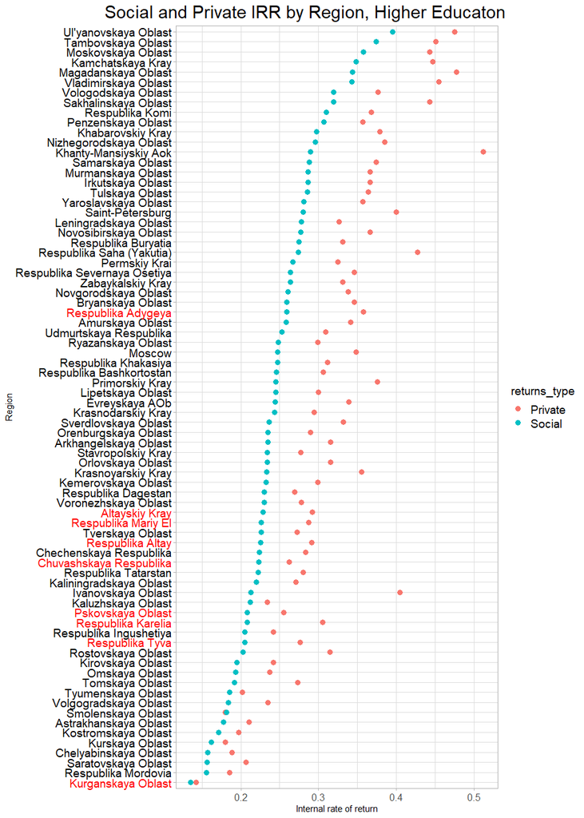

[output not shown]

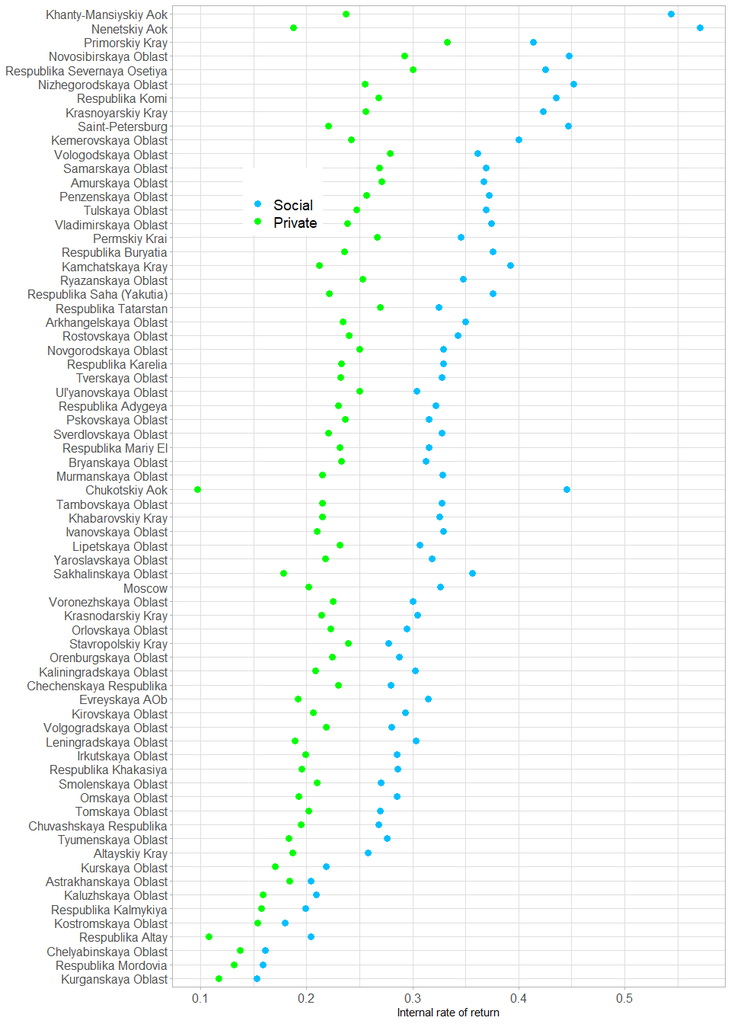

[output not shown]

[output not shown]

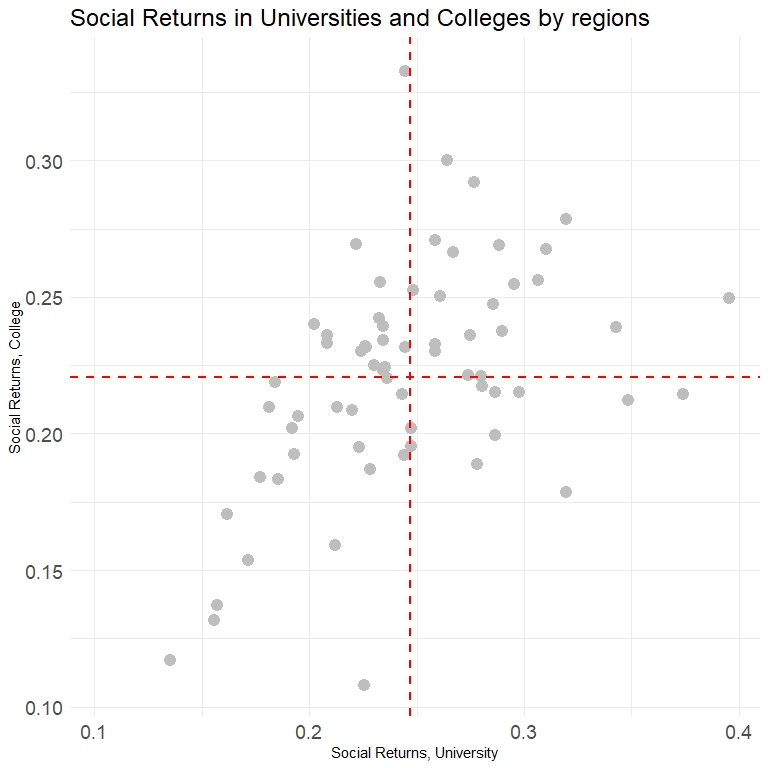

[output not shown]

[figure not shown]

# 3. Organizational Returns

Data provided by graduate.edu allow us to calculate IRR directly for each educational organization. As in the previous part we use social and private cost as the cost part of the IRR specification, but now we utilize graduate salaries in 2014, 2015, and 2016 as the benefits obtained by the graduates. Resulting IRR estimations have a negative sign for most of the organizations since we have access only to the 3 years of observations after graduation. However such estimates still can be used to compare universities or colleges with each other.

Bellow, you can the tables with Top-10 and Bottom-10 universities/colleges ranked according to the social IRR.

| social returns | private returns | name | region | income | fee income | graduates number | salary 2014 | salary 2015 | salary 2016 |
| --- | --- | --- | --- | --- | --- | --- | --- | --- | --- |
| 0.07 | 0.09 | Бурятская государственная сельскохозяйственная академия имени В. Р. Филиппова | Respublika Buryatia | 16419973 | 2135936 | 415 | 361213.896 | 360858.456 | 349404 |
| 0.05 | 0.09 | Российский государственный университет туризма и сервиса | Moskovskaya Oblast | 1100392770 | 687722327 | 3019 | 500777.184 | 469830.564 | 477228 |
| 0.05 | 0.07 | Тюменский индустриальный университет | Tyumenskaya Oblast | 4183964503 | 3062237486 | 6655 | 891604.86 | 857896.704 | 891600 |
| 0.04 | 0.07 | Самарский государственный экономический университет | Samarskaya Oblast | 772501080 | 617780376 | 1826 | 422044.608 | 425953.836 | 438048 |
| 0.04 | 0.2 | Северо-Восточный государственный университет | Magadanskaya Oblast | 523571221 | 90276607 | 573 | 758097.924 | 772636.536 | 718128 |
| 0.04 | 0.1 | Сибирский государственный индустриальный университет | Kemerovskaya Oblast | 541798925 | 207680607 | 1727 | 394167.576 | 390559.428 | 406224 |
| 0.04 | 0.13 | Самарский государственный технический университет | Samarskaya Oblast | 2635986297 | 1474296345 | 2879 | 588119.28 | 601473.6 | 624144 |
| 0.03 | 0.09 | Сибирский государственный университет геосистем и технологий | Novosibirskaya Oblast | 652983402 | 341877460 | 1768 | 364479.576 | 359817.444 | 358824 |
| 0.03 | 0.1 | Камчатский государственный технический университет | Kamchatskaya Kray | 533540405 | 232659966 | 826 | 570974.46 | 681760.044 | 707748 |
| 0.02 | 0.15 | Арктический государственный институт культуры и искусств | Respublika Saha (Yakutia) | 221197434 | 45218603 | 366 | 477293.976 | 516393.36 | 527172 |
| ... | ... | ... | ... | ... | ... | ... | ... | ... | ... |
| -0.29 | -0.18 | Самарский государственный медицинский университет Минздрава России | Samarskaya Oblast | 2808462605 | 1435110302 | 1169 | 304480.128 | 336323.988 | 332664 |
| -0.3 | -0.13 | Российский национальный исследовательский медицинский университет имени Н. И. Пирогова Минздрава России | Moscow | 5036024164 | 1518805539 | 1165 | 476878.344 | 615520.836 | 650520 |
| -0.3 | -0.22 | Астраханский государственный архитектурно-строительный университет | Astrakhanskaya Oblast | 325385006 | 68334706 | 282 | 304302 | 294747.768 | 304896 |
| -0.3 | -0.1 | Московская государственная художественно-промышленная академия им. С. Г. Строганова | Moscow | 737231046 | 135743693 | 196 | 449416.944 | 683109.504 | 456420 |
| -0.3 | -0.17 | Сибирский государственный медицинский университет Минздрава России | Tomskaya Oblast | 2017650593 | 820981827 | 630 | 338235.384 | 409477.572 | 435996 |
| -0.31 | -0.16 | Брянский государственный аграрный университет | Bryanskaya Oblast | 692626466 | 187517317 | 408 | 247969.02 | 248377.752 | 257100 |
| -0.31 | -0.14 | Национальный исследовательский технологический университет «МИСиС» | Moscow | 6407021047 | 1860200816 | 1394 | 571108.056 | 574587.216 | 615612 |
| -0.32 | -0.18 | Северо-Западный государственный медицинский университет имени И. И. Мечникова Минздрава России | Saint-Petersburg | 4976035086 | 2229931339 | 949 | 483691.74 | 529271.064 | 566856 |
| -0.34 | -0.16 | Саратовская государственная консерватория имени Л. В. Собинова | Saratovskaya Oblast | 254287233 | 16350307 | 116 | 313980.288 | 313434.576 | 304608 |
| -0.35 | -0.15 | Уральский государственный аграрный университет | Sverdlovskaya Oblast | 779596081 | 183471177 | 260 | 320125.704 | 307355.58 | 304932 |

[output not shown]

| social returns | private returns | name | region | income | fee income | graduates number | salary 2014 | salary 2015 | salary 2016 |
| --- | --- | --- | --- | --- | --- | --- | --- | --- | --- |
| 0.13 | 0.35 | Самарский энергетический колледж | Samarskaya Oblast | 77494648 | 15863750 | 140 | 539416.116 | 484520.4 | 508356 |
| 0.13 | 0.22 | Томский политехнический техникум | Tomskaya Oblast | 92245066 | 28143249 | 306 | 480500.28 | 479186.82 | 505800 |
| 0.12 | 0.24 | Новочеркасский геологоразведочный колледж | Rostovskaya Oblast | 65409748 | 11559321 | 244 | 465314.868 | 379082.592 | 411528 |
| 0.12 | 0.28 | Вилюйский техникум | Respublika Saha (Yakutia) | 52924188 | 2300450 | 156 | 425013.408 | 426275.136 | 454404 |
| 0.11 | 0.21 | Киселевский горный техникум | Kemerovskaya Oblast | 55748751 | 8735011 | 280 | 313505.28 | 352453.248 | 359652 |
| 0.11 | 0.25 | Высшая банковская школа | Saint-Petersburg | 63656896 | 6861353 | 229 | 410139.72 | 371384.244 | 397116 |
| 0.11 | 0.24 | Промышленно-технологический колледж | Saint-Petersburg | 71753379 | 1316861 | 305 | 367166.34 | 383850.684 | 352680 |
| 0.1 | 0.18 | Пермский нефтяной колледж | Permskiy Krai | 64188098 | 31136275 | 171 | 502231.896 | 486949.428 | 515604 |
| 0.1 | 0.3 | Якутский автодорожный техникум | Respublika Saha (Yakutia) | 102647775 | 12136284 | 220 | 516749.328 | 425799.612 | 473868 |
| 0.1 | 0.19 | Сахалинский промышленно-экономический техникум | Sakhalinskaya Oblast | 170093710 | 53870817 | 489 | 510811.728 | 470498.868 | 487980 |
| ... | ... | ... | ... | ... | ... | ... | ... | ... | ... |
| -0.32 | -0.04 | Абаканский строительный техникум | Respublika Khakasiya | 102510593 | 2504406 | 70 | 230779.668 | 246167.208 | 229092 |
| -0.32 | -0.24 | Ичалковский педагогический колледж | Respublika Mordovia | 40375002 | 2698852 | 62 | 246083.832 | 236284.02 | 216048 |
| -0.32 | -0.19 | Озерский технический колледж | Chelyabinskaya Oblast | 217475527 | 23639667 | 154 | 277849.992 | 311082.66 | 325056 |
| -0.32 | 0.04 | Колледж метростроя | Saint-Petersburg | 121820668 | 11148350 | 55 | 304109.028 | 278926.956 | 286884 |
| -0.32 | -0.16 | Калужский технический колледж | Kaluzhskaya Oblast | 210753603 | 12964108 | 154 | 305801.244 | 275302.692 | 263820 |
| -0.33 | -0.02 | Емельяновский дорожно-строительный техникум | Krasnoyarskiy Kray | 126101858 | 15068464 | 73 | 259428.588 | 238507.416 | 219576 |
| -0.33 | -0.14 | Технологический колледж № 21 | Moscow | 382506424 | 44584864 | 216 | 303114.48 | 286252.596 | 307524 |
| -0.33 | 0.12 | Сахалинский техникум механизации сельского хозяйства | Sakhalinskaya Oblast | 295523466 | 14124141 | 82 | 484255.812 | 400686.804 | 422424 |
| -0.34 | 0.15 | Колледж «Красносельский» | Saint-Petersburg | 183183432 | 752462 | 74 | 296865.156 | 316866.06 | 277284 |
| -0.34 | -0.02 | Краснодарский педагогический колледж | Krasnodarskiy Kray | 264550658 | 6833323 | 148 | 284707.92 | 239625.54 | 226572 |

[output not shown]

[figure not shown]

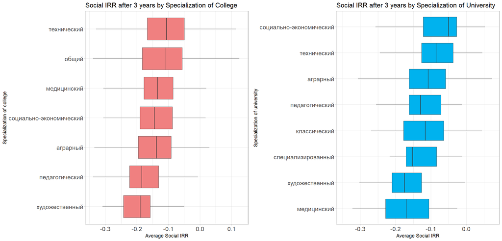

[figure not shown]

We estimate the factors which are explaining the difference in returns between organization by conducting 4 separate linear regression models with 1) Social IRR in colleges, 2) Private IRR in colleges, 3) Social IRR in universities, and 4) Private IRR in universities as dependent variables. We are going to use 1) the specialization of organization, 2) the number of graduates, 3) the number of staff, 4) the average wage in the organization, 5) the proportion of income obtained from paid services and 6) the average wage in the region as the main predictors for these models.